# Sta-209-04 (Spring 24) Homework #4 (rough soln)

From the Introduction to Modern Statistics (IMS) textbook, complete the following exercises:

- Ch 7.5 Exercises: #6, #8

Also complete the additional questions given below:

**Question #1**: This question uses data from a large, public university facing accusations of sex-based discrimination in its graduate school admissions. The data set includes each admission decision for the 6 largest graduate departments. Each applicant was given an anonymous identifier.

```r
adm = read.csv("https://remiller1450.github.io/data/admissions.csv")
```

- **Part A**: Create a two-way frequency table, then use conditional proportions to compare the proportion of male applicants that were admitted with the proportion of female applicants that were admitted.
- **Part B**: Create an appropriate type of bar chart that shows the relationship between the variables `dept` and `sex`. Briefly explain how these variables are related.
- **Part C**: Create an appropriate type of bar chart that shows the relationship between the variables `dept` and `admit`. Briefly explain how these variables are related.
- **Part D**: Is the variable `dept` confounding the relationship between the variables `sex` and `admit`? Briefly explain.
- **Part E**: Find and compare the proportion of male applicants that were admitted with the proportion of female applicants that were admitted *within department “A”*. *Hint*: use the `filter()` function to create a data set containing only cases that applied to department A.
- **Part F**: Is this an example of *Simpson’s Paradox*? Briefly explain.

```r
## PART A
pa_tab = table(adm$sex, adm$admit)
prop.table(pa_tab, margin = 1)
```

```
##
##             N         Y
##   F 0.8066997 0.1933003
##   M 0.7610337 0.2389663
```

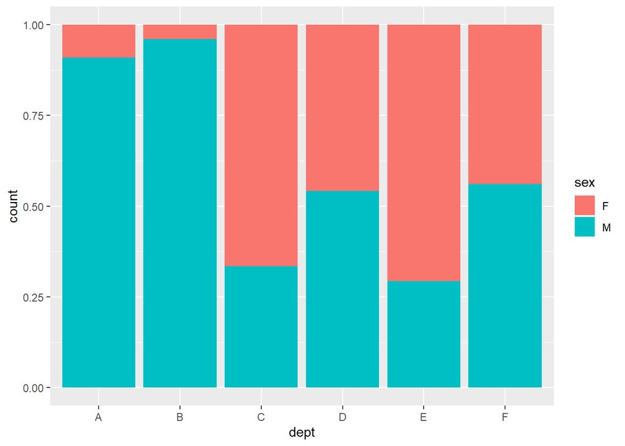

```r
# 23.9% of males are admitted vs. only 19.3% of females, so there seems to be an association.

## PART B
ggplot(adm, aes(x = dept, fill = sex)) + geom_bar(position = "fill")
```

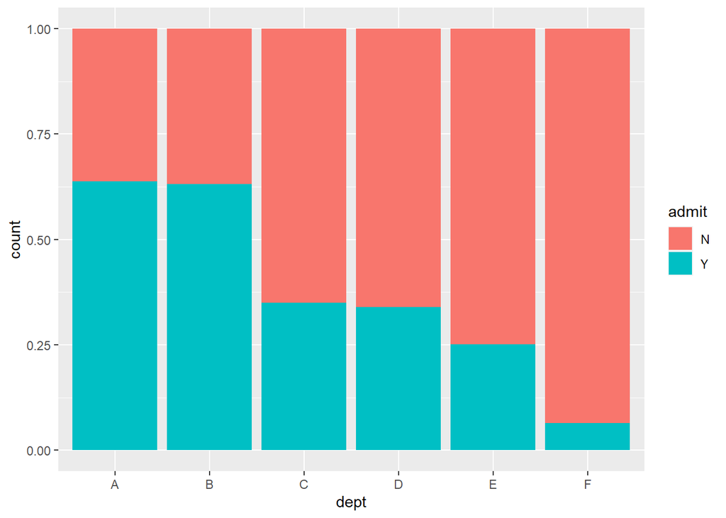

```r
# There is a strong association between sex and department. Departments A and B predominately receive male applications, while the others are close to 50-50 or majority female.

## Part C
ggplot(adm, aes(x = dept, fill = admit)) + geom_bar(position = "fill")
```

```r
# The variables dept and admit are associated. Departments A and B admit more than half of their applicants, while the others admit substantially lower proportions.

## Part D
# YES - the defn of confounding is met since dept is associated with both the explanatory variable, sex, and the response variable, admit, in this comparison.

## Part E
adm_deptA = adm %>% filter(dept == "A")
prop.table(table(adm_deptA$sex, adm_deptA$admit), margin = 1)
```

```
##
##             N         Y
##   F 0.1818182 0.8181818
##   M 0.3801653 0.6198347
```

```r
# W/in dept A, 81.82% of females were admitted but only 61.98% of males were admitted.

## PART F
# Yes - the direction of association seems to reverse in the stratified analysis. That is, when the data are analyzed as a whole it appears that females are admitted at lower rates. However, females are admitted at higher rates or approximately equal rates within every department (we only looked at one, but you can confirm that this tends to be true of all of them)
```

$~$

**Question #2**: This question uses team data for each of the 82 regular season games played by the Golden State Warriors during their record setting 2015-16 season.

```r
gsw = read.csv("https://remiller1450.github.io/data/GSWarriors.csv")
```

- **Part A**: Use the `mutate()` function in the `dplyr` package to create a new variable called “pt_margin” that is the difference between the points scored by the Warriors (ie: `Points`) and the points scored by their opponent (ie: `OppPoints`). This variable should have positive values when the Warriors outscored their opponent. *Hint*: The `mutate()` function was covered in the [`dplyr` lab](https://remiller1450.github.io/s209s24/dplyr.html).
- **Part B**: Create a scatter plot showing the relationship between the variables `FG3A` (the number of 3-point shot attempts by the Warriors) and the variable `pt_margin` (that you created in Part A). Briefly describe the relationship between these two variables.
- **Part C**: Add a “loess” smoother to the scatter plot from Part B and decide whether Pearson’s correlation or Spearman’s rank correlation is the more appropriate measure of association. Then, find and report the appropriate correlation coefficient.
- **Part D**: Fit a simple linear regression model that uses the response variable `pt_margin` and the explanatory variable `FG3A`. Interpret the estimated slope coefficient for the variable `FG3A`.
- **Part E**: Now fit a multivariable regression using the response variable `pt_margin` and the explanatory variables `FG3` (the number of *made* 3-point shots) and `FG3A`. Interpret the estimated slope coefficient for the variable `FG3A`.
- **Part F**: In your own words, explain why the coefficient of `FG3A` is very different in the model from Part E when compared to its value in the model from Part D.
- **Part G**: Fit a multivariable regression model that uses the explanatory variables `Location` and `FG3` to predict the response variable `pt_margin`. Interpret the estimated coefficient of the re-coded variable `LocationHome`.
- **Part H**: Now remove the explanatory variable `FG3` from the model you fit Part G (ie: fit a regression model with the single predictor `Location` and the response variable `pt_margin`). Provide a brief explanation as to why the estimated coefficient of the re-coded variable `LocationHome` in this model is approximately the same as the estimated coefficient of this variable in the model from Part G (which also included `FG3`).

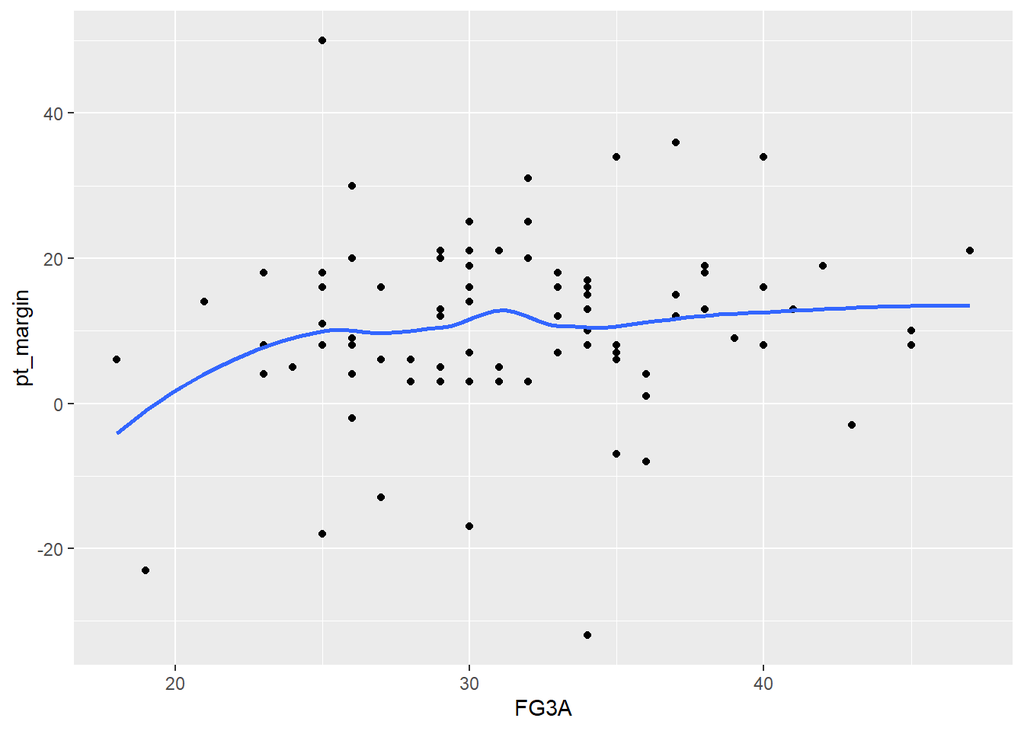

```r
## PART A
gsw = gsw %>% mutate(pt_margin = Points - OppPoints)

## PART B
ggplot(gsw, aes(x = FG3A, y = pt_margin)) + geom_point() + geom_smooth(method = "loess", se = FALSE)
```

```r
# Weak, positive relationship - saying either linear or non-linear is acceptable

## PART C
# Note - LOESS smoother added in Part B solution here
# If they said "non-linear" in B, they should be using "spearman"
# If they said "linear" in B, they should be using "pearson"
# Either is fine, as long as they are consistent w/ what they said in Part B or when describing the LOESS pattern.
cor(gsw$FG3A, gsw$pt_margin, method = "spearman")
```

```
## [1] 0.1335925
```

```r
## PART D
pd_mod = lm(pt_margin ~ FG3A, data = gsw)
coef(pd_mod)
```

```
## (Intercept)        FG3A
##   1.7459665   0.2850427
```

```r
## Each additional 3-point shot attempt is expected to increase the Warrior's pt margin by +0.285 points

## PART E
pd_mod = lm(pt_margin ~ FG3 + FG3A, data = gsw)
coef(pd_mod)
```

```
## (Intercept)         FG3        FG3A
##   3.3479640   1.6540520  -0.4529117
```

```r
## For a fixed number of made 3-point shots, each additional shot attempt required to reach that number of makes decreases the expected margin by 0.453

## PART F
# The coefficient in Part E is conditional on a fixed number of made 3s. So, if more attempts are taken for the same amount of made shots the team's performance was worse, hence the negative coefficient. It would also be acceptable to say that FG3 and FG3A are positive correlated.

## PART G
pg_mod = lm(pt_margin ~ Location + FG3, data = gsw)
coef(pg_mod)
```

```
##  (Intercept) LocationHome          FG3
##    -9.046411     7.477109     1.223068
```

```r
# Given the number of made 3-pointers remains constant, the Warriors are expected to have a pt margin that is 7.477 pts higher at home than it is when they are away.

## PART H
ph_mod = lm(pt_margin ~ Location, data = gsw)
coef(ph_mod)
```

```
##  (Intercept) LocationHome
##     7.121951     7.268293
```

```r
# It's nearly the same because FG3 isn't associated w/ location
# that is, FG3 doesn't confound the relationship between location and pt_margin
```

$~$

### Submission instructions

- Use R Markdown to create a document containing your answers and any R code used.